# Risk Factor Analysis

## Outcome Variable

**Outcome Variable:** stunted

## Predictor Variables

**Intervention Variable:** hdlvry

**Adjustment Set:**

- arm
- sex
- W_mage
- meducyrs
- feducyrs
- hhwealth_quart
- single
- W_nrooms
- brthmon
- W_parity
- impsan
- delta_W_mage
- delta_meducyrs
- delta_feducyrs
- delta_hhwealth_quart
- delta_single
- delta_W_nrooms
- delta_brthmon
- delta_W_parity
- delta_impsan

## Stratifying Variables

The analysis was stratified on these variable(s):

- agecat
- studyid
- country

## Data Summary

| agecat | studyid | country | hdlvry | stunted | n_cell | n |
| --- | --- | --- | --- | --- | --- | --- |
| Birth | CMC-V-BCS-2002 | INDIA | 0 | 0 | 75 | 92 |
| Birth | CMC-V-BCS-2002 | INDIA | 0 | 1 | 17 | 92 |
| Birth | CMC-V-BCS-2002 | INDIA | 1 | 0 | 0 | 92 |
| Birth | CMC-V-BCS-2002 | INDIA | 1 | 1 | 0 | 92 |
| Birth | COHORTS | INDIA | 0 | 0 | 2613 | 4694 |
| Birth | COHORTS | INDIA | 0 | 1 | 325 | 4694 |
| Birth | COHORTS | INDIA | 1 | 0 | 1534 | 4694 |
| Birth | COHORTS | INDIA | 1 | 1 | 222 | 4694 |
| Birth | EE | PAKISTAN | 0 | 0 | 93 | 238 |
| Birth | EE | PAKISTAN | 0 | 1 | 68 | 238 |
| Birth | EE | PAKISTAN | 1 | 0 | 46 | 238 |
| Birth | EE | PAKISTAN | 1 | 1 | 31 | 238 |
| Birth | GMS-Nepal | NEPAL | 0 | 0 | 125 | 646 |
| Birth | GMS-Nepal | NEPAL | 0 | 1 | 32 | 646 |
| Birth | GMS-Nepal | NEPAL | 1 | 0 | 408 | 646 |
| Birth | GMS-Nepal | NEPAL | 1 | 1 | 81 | 646 |
| Birth | IRC | INDIA | 0 | 0 | 337 | 388 |
| Birth | IRC | INDIA | 0 | 1 | 44 | 388 |
| Birth | IRC | INDIA | 1 | 0 | 6 | 388 |
| Birth | IRC | INDIA | 1 | 1 | 1 | 388 |
| Birth | JiVitA-3 | BANGLADESH | 0 | 0 | 23 | 334 |
| Birth | JiVitA-3 | BANGLADESH | 0 | 1 | 7 | 334 |
| Birth | JiVitA-3 | BANGLADESH | 1 | 0 | 220 | 334 |
| Birth | JiVitA-3 | BANGLADESH | 1 | 1 | 84 | 334 |
| Birth | JiVitA-4 | BANGLADESH | 0 | 0 | 420 | 2808 |
| Birth | JiVitA-4 | BANGLADESH | 0 | 1 | 134 | 2808 |
| Birth | JiVitA-4 | BANGLADESH | 1 | 0 | 1535 | 2808 |
| Birth | JiVitA-4 | BANGLADESH | 1 | 1 | 719 | 2808 |
| Birth | NIH-Crypto | BANGLADESH | 0 | 0 | 495 | 732 |
| Birth | NIH-Crypto | BANGLADESH | 0 | 1 | 72 | 732 |

[output cut: 98 more lines]

The following strata were considered:

- agecat: 24 months, studyid: CMC-V-BCS-2002, country: INDIA
- agecat: 24 months, studyid: COHORTS, country: INDIA
- agecat: 24 months, studyid: EE, country: PAKISTAN
- agecat: 24 months, studyid: GMS-Nepal, country: NEPAL
- agecat: 24 months, studyid: IRC, country: INDIA
- agecat: 24 months, studyid: JiVitA-3, country: BANGLADESH
- agecat: 24 months, studyid: JiVitA-4, country: BANGLADESH
- agecat: 24 months, studyid: NIH-Crypto, country: BANGLADESH
- agecat: 24 months, studyid: PROVIDE, country: BANGLADESH
- agecat: 24 months, studyid: TanzaniaChild2, country: TANZANIA, UNITED REPUBLIC OF
- agecat: 6 months, studyid: CMC-V-BCS-2002, country: INDIA
- agecat: 6 months, studyid: COHORTS, country: INDIA
- agecat: 6 months, studyid: EE, country: PAKISTAN
- agecat: 6 months, studyid: GMS-Nepal, country: NEPAL
- agecat: 6 months, studyid: IRC, country: INDIA
- agecat: 6 months, studyid: JiVitA-3, country: BANGLADESH
- agecat: 6 months, studyid: JiVitA-4, country: BANGLADESH
- agecat: 6 months, studyid: NIH-Crypto, country: BANGLADESH
- agecat: 6 months, studyid: PROVIDE, country: BANGLADESH
- agecat: 6 months, studyid: SAS-CompFeed, country: INDIA
- agecat: 6 months, studyid: SAS-FoodSuppl, country: INDIA
- agecat: 6 months, studyid: TanzaniaChild2, country: TANZANIA, UNITED REPUBLIC OF
- agecat: Birth, studyid: CMC-V-BCS-2002, country: INDIA
- agecat: Birth, studyid: COHORTS, country: INDIA
- agecat: Birth, studyid: EE, country: PAKISTAN
- agecat: Birth, studyid: GMS-Nepal, country: NEPAL
- agecat: Birth, studyid: IRC, country: INDIA
- agecat: Birth, studyid: JiVitA-3, country: BANGLADESH
- agecat: Birth, studyid: JiVitA-4, country: BANGLADESH
- agecat: Birth, studyid: NIH-Crypto, country: BANGLADESH
- agecat: Birth, studyid: PROVIDE, country: BANGLADESH
- agecat: Birth, studyid: SAS-CompFeed, country: INDIA

### Dropped Strata

Some strata were dropped due to rare outcomes:

- agecat: Birth, studyid: CMC-V-BCS-2002, country: INDIA
- agecat: Birth, studyid: IRC, country: INDIA
- agecat: 6 months, studyid: CMC-V-BCS-2002, country: INDIA
- agecat: 6 months, studyid: IRC, country: INDIA
- agecat: 24 months, studyid: CMC-V-BCS-2002, country: INDIA
- agecat: 24 months, studyid: IRC, country: INDIA
- agecat: 24 months, studyid: TanzaniaChild2, country: TANZANIA, UNITED REPUBLIC OF

## Methods Detail

We’re interested in the causal parameters $E[Y_a]$ for all values of $a \in \mathcal{A}$. These parameters represent the mean outcome if, possibly contrary to fact, we intervened to set all units to have $A=a$. Under the randomization and positivity assumptions, these are identified by the statistical parameters $\psi_a=E_W[E_{Y|A,W}(Y|A=a,W)]$. In addition, we’re interested in the mean of $Y$, $E[Y]$ under no intervention (the observed mean). We will estimate these parameters by using SuperLearner to fit the relevant likelihood factors – $E_{Y|A,W}(Y|A=a,W)$ and $p(A=a|W)$, and then updating our likelihood fit using a joint TMLE.

For unadjusted analyses ($W=\{\}$), initial likelihoods were estimated using Lrnr_glm to estimate the simple $E(Y|A)$ and Lrnr_mean to estimate $p(A)$. For adjusted analyses, a small library containing Lrnr_glmnet, Lrnr_xgboost, and Lrnr_mean was used.

Having estimated these parameters, we will then use the delta method to estimate relative risks and attributable risks relative to a prespecified baseline level of $A$.

# Results Detail

## Results Plots

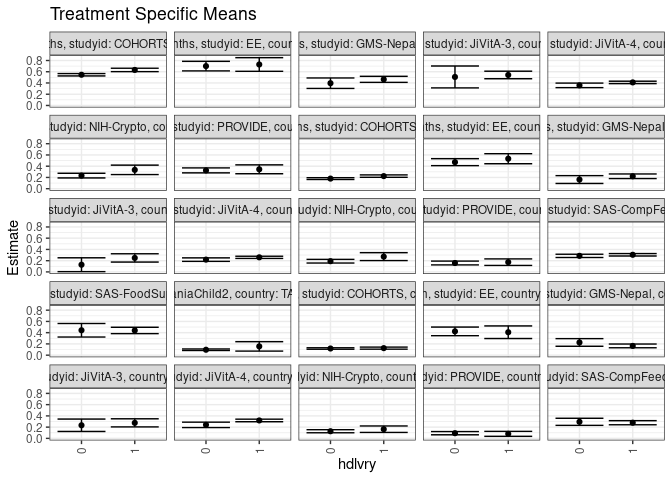

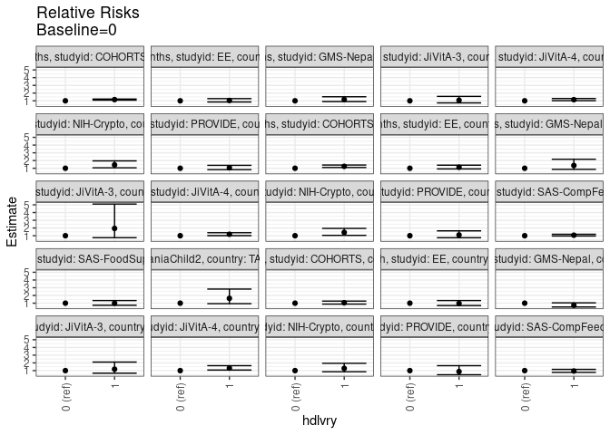

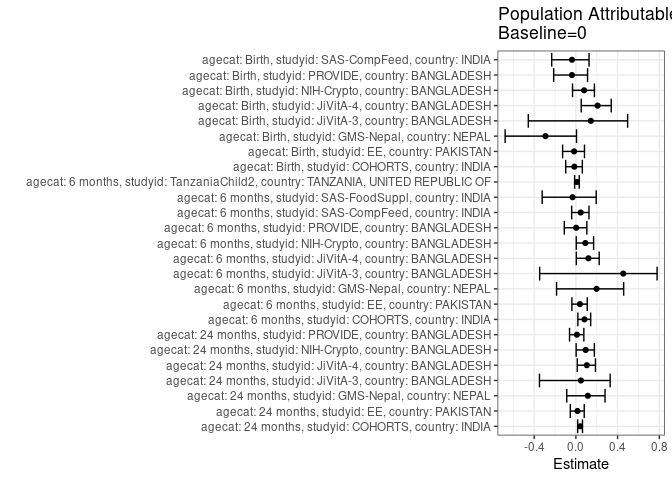

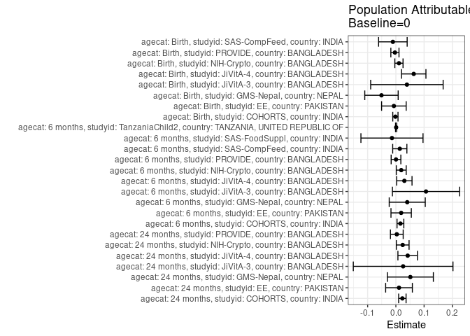

## Results Table

### Parameter: TSM

| agecat | studyid | country | intervention_level | baseline_level | estimate | ci_lower | ci_upper |
| --- | --- | --- | --- | --- | --- | --- | --- |
| Birth | COHORTS | INDIA | 0 | NA | 0.1182522 | 0.1050275 | 0.1314770 |
| Birth | COHORTS | INDIA | 1 | NA | 0.1247895 | 0.1066092 | 0.1429698 |
| Birth | EE | PAKISTAN | 0 | NA | 0.4230464 | 0.3464034 | 0.4996895 |
| Birth | EE | PAKISTAN | 1 | NA | 0.4076450 | 0.2956338 | 0.5196561 |
| Birth | GMS-Nepal | NEPAL | 0 | NA | 0.2259596 | 0.1581173 | 0.2938019 |
| Birth | GMS-Nepal | NEPAL | 1 | NA | 0.1643076 | 0.1310537 | 0.1975616 |
| Birth | JiVitA-3 | BANGLADESH | 0 | NA | 0.2333333 | 0.1228972 | 0.3437694 |
| Birth | JiVitA-3 | BANGLADESH | 1 | NA | 0.2763158 | 0.2043428 | 0.3482888 |
| Birth | JiVitA-4 | BANGLADESH | 0 | NA | 0.2405307 | 0.1927093 | 0.2883521 |
| Birth | JiVitA-4 | BANGLADESH | 1 | NA | 0.3191092 | 0.2961921 | 0.3420262 |
| Birth | NIH-Crypto | BANGLADESH | 0 | NA | 0.1271094 | 0.0996493 | 0.1545694 |
| Birth | NIH-Crypto | BANGLADESH | 1 | NA | 0.1636453 | 0.1059862 | 0.2213043 |
| Birth | PROVIDE | BANGLADESH | 0 | NA | 0.0924316 | 0.0637653 | 0.1210978 |
| Birth | PROVIDE | BANGLADESH | 1 | NA | 0.0808945 | 0.0367063 | 0.1250826 |
| Birth | SAS-CompFeed | INDIA | 0 | NA | 0.2944865 | 0.2312328 | 0.3577403 |
| Birth | SAS-CompFeed | INDIA | 1 | NA | 0.2788971 | 0.2426333 | 0.3151609 |
| 6 months | COHORTS | INDIA | 0 | NA | 0.1794439 | 0.1633793 | 0.1955084 |
| 6 months | COHORTS | INDIA | 1 | NA | 0.2237785 | 0.2025892 | 0.2449678 |
| 6 months | EE | PAKISTAN | 0 | NA | 0.4718582 | 0.4097663 | 0.5339501 |
| 6 months | EE | PAKISTAN | 1 | NA | 0.5331870 | 0.4440480 | 0.6223260 |
| 6 months | GMS-Nepal | NEPAL | 0 | NA | 0.1623890 | 0.0927961 | 0.2319819 |
| 6 months | GMS-Nepal | NEPAL | 1 | NA | 0.2208663 | 0.1798937 | 0.2618388 |
| 6 months | JiVitA-3 | BANGLADESH | 0 | NA | 0.1282051 | 0.0052540 | 0.2511562 |
| 6 months | JiVitA-3 | BANGLADESH | 1 | NA | 0.2491468 | 0.1752336 | 0.3230600 |
| 6 months | JiVitA-4 | BANGLADESH | 0 | NA | 0.2188747 | 0.1877663 | 0.2499832 |
| 6 months | JiVitA-4 | BANGLADESH | 1 | NA | 0.2597228 | 0.2399843 | 0.2794613 |
| 6 months | NIH-Crypto | BANGLADESH | 0 | NA | 0.1907954 | 0.1581034 | 0.2234873 |
| 6 months | NIH-Crypto | BANGLADESH | 1 | NA | 0.2720454 | 0.2016648 | 0.3424261 |
| 6 months | PROVIDE | BANGLADESH | 0 | NA | 0.1584877 | 0.1247792 | 0.1921961 |
| 6 months | PROVIDE | BANGLADESH | 1 | NA | 0.1737290 | 0.1155728 | 0.2318852 |
| 6 months | SAS-CompFeed | INDIA | 0 | NA | 0.2858538 | 0.2567494 | 0.3149583 |
| 6 months | SAS-CompFeed | INDIA | 1 | NA | 0.3049065 | 0.2833263 | 0.3264868 |
| 6 months | SAS-FoodSuppl | INDIA | 0 | NA | 0.4427692 | 0.3224504 | 0.5630880 |
| 6 months | SAS-FoodSuppl | INDIA | 1 | NA | 0.4393015 | 0.3827468 | 0.4958562 |
| 6 months | TanzaniaChild2 | TANZANIA, UNITED REPUBLIC OF | 0 | NA | 0.0963473 | 0.0829238 | 0.1097708 |
| 6 months | TanzaniaChild2 | TANZANIA, UNITED REPUBLIC OF | 1 | NA | 0.1562500 | 0.0724034 | 0.2400966 |
| 24 months | COHORTS | INDIA | 0 | NA | 0.5461748 | 0.5250041 | 0.5673455 |
| 24 months | COHORTS | INDIA | 1 | NA | 0.6318826 | 0.6017282 | 0.6620369 |
| 24 months | EE | PAKISTAN | 0 | NA | 0.6997500 | 0.6147648 | 0.7847353 |
| 24 months | EE | PAKISTAN | 1 | NA | 0.7287143 | 0.6075487 | 0.8498799 |
| 24 months | GMS-Nepal | NEPAL | 0 | NA | 0.3959806 | 0.3028122 | 0.4891490 |
| 24 months | GMS-Nepal | NEPAL | 1 | NA | 0.4644112 | 0.4109942 | 0.5178282 |
| 24 months | JiVitA-3 | BANGLADESH | 0 | NA | 0.5069327 | 0.3120690 | 0.7017964 |
| 24 months | JiVitA-3 | BANGLADESH | 1 | NA | 0.5423682 | 0.4753175 | 0.6094189 |
| 24 months | JiVitA-4 | BANGLADESH | 0 | NA | 0.3574035 | 0.3172986 | 0.3975083 |
| 24 months | JiVitA-4 | BANGLADESH | 1 | NA | 0.4100986 | 0.3886139 | 0.4315833 |
| 24 months | NIH-Crypto | BANGLADESH | 0 | NA | 0.2326672 | 0.1912127 | 0.2741216 |
| 24 months | NIH-Crypto | BANGLADESH | 1 | NA | 0.3349369 | 0.2508455 | 0.4190282 |
| 24 months | PROVIDE | BANGLADESH | 0 | NA | 0.3253931 | 0.2813581 | 0.3694282 |
| 24 months | PROVIDE | BANGLADESH | 1 | NA | 0.3448217 | 0.2659582 | 0.4236852 |

### Parameter: E(Y)

| agecat | studyid | country | intervention_level | baseline_level | estimate | ci_lower | ci_upper |
| --- | --- | --- | --- | --- | --- | --- | --- |
| Birth | COHORTS | INDIA | NA | NA | 0.1165317 | 0.1073518 | 0.1257117 |
| Birth | EE | PAKISTAN | NA | NA | 0.4159664 | 0.3532152 | 0.4787176 |
| Birth | GMS-Nepal | NEPAL | NA | NA | 0.1749226 | 0.1456043 | 0.2042409 |
| Birth | JiVitA-3 | BANGLADESH | NA | NA | 0.2724551 | 0.2076543 | 0.3372559 |
| Birth | JiVitA-4 | BANGLADESH | NA | NA | 0.3037749 | 0.2834613 | 0.3240886 |
| Birth | NIH-Crypto | BANGLADESH | NA | NA | 0.1379781 | 0.1129774 | 0.1629789 |
| Birth | PROVIDE | BANGLADESH | NA | NA | 0.0890538 | 0.0649864 | 0.1131212 |
| Birth | SAS-CompFeed | INDIA | NA | NA | 0.2838710 | 0.2475589 | 0.3201830 |
| 6 months | COHORTS | INDIA | NA | NA | 0.1955735 | 0.1842315 | 0.2069155 |
| 6 months | EE | PAKISTAN | NA | NA | 0.4905660 | 0.4396283 | 0.5415038 |
| 6 months | GMS-Nepal | NEPAL | NA | NA | 0.2026515 | 0.1683319 | 0.2369711 |
| 6 months | JiVitA-3 | BANGLADESH | NA | NA | 0.2349398 | 0.1664503 | 0.3034292 |
| 6 months | JiVitA-4 | BANGLADESH | NA | NA | 0.2488856 | 0.2328153 | 0.2649558 |
| 6 months | NIH-Crypto | BANGLADESH | NA | NA | 0.2097902 | 0.1799252 | 0.2396552 |
| 6 months | PROVIDE | BANGLADESH | NA | NA | 0.1589404 | 0.1297581 | 0.1881227 |
| 6 months | SAS-CompFeed | INDIA | NA | NA | 0.2997250 | 0.2767096 | 0.3227405 |
| 6 months | SAS-FoodSuppl | INDIA | NA | NA | 0.4289474 | 0.3791199 | 0.4787748 |
| 6 months | TanzaniaChild2 | TANZANIA, UNITED REPUBLIC OF | NA | NA | 0.0973451 | 0.0840860 | 0.1106043 |
| 24 months | COHORTS | INDIA | NA | NA | 0.5691789 | 0.5529008 | 0.5854569 |
| 24 months | EE | PAKISTAN | NA | NA | 0.7108434 | 0.6416667 | 0.7800200 |
| 24 months | GMS-Nepal | NEPAL | NA | NA | 0.4473684 | 0.4016814 | 0.4930554 |
| 24 months | JiVitA-3 | BANGLADESH | NA | NA | 0.5326460 | 0.4663548 | 0.5989373 |
| 24 months | JiVitA-4 | BANGLADESH | NA | NA | 0.3992509 | 0.3804088 | 0.4180930 |
| 24 months | NIH-Crypto | BANGLADESH | NA | NA | 0.2568093 | 0.2190047 | 0.2946140 |
| 24 months | PROVIDE | BANGLADESH | NA | NA | 0.3287197 | 0.2903909 | 0.3670485 |

### Parameter: RR

| agecat | studyid | country | intervention_level | baseline_level | estimate | ci_lower | ci_upper |
| --- | --- | --- | --- | --- | --- | --- | --- |
| Birth | COHORTS | INDIA | 0 | 0 | 1.0000000 | 1.0000000 | 1.000000 |
| Birth | COHORTS | INDIA | 1 | 0 | 1.0552819 | 0.8784438 | 1.267719 |
| Birth | EE | PAKISTAN | 0 | 0 | 1.0000000 | 1.0000000 | 1.000000 |
| Birth | EE | PAKISTAN | 1 | 0 | 0.9635940 | 0.6937304 | 1.338435 |
| Birth | GMS-Nepal | NEPAL | 0 | 0 | 1.0000000 | 1.0000000 | 1.000000 |
| Birth | GMS-Nepal | NEPAL | 1 | 0 | 0.7271548 | 0.5062300 | 1.044494 |
| Birth | JiVitA-3 | BANGLADESH | 0 | 0 | 1.0000000 | 1.0000000 | 1.000000 |
| Birth | JiVitA-3 | BANGLADESH | 1 | 0 | 1.1842105 | 0.6662901 | 2.104721 |
| Birth | JiVitA-4 | BANGLADESH | 0 | 0 | 1.0000000 | 1.0000000 | 1.000000 |
| Birth | JiVitA-4 | BANGLADESH | 1 | 0 | 1.3266877 | 1.0725140 | 1.641098 |
| Birth | NIH-Crypto | BANGLADESH | 0 | 0 | 1.0000000 | 1.0000000 | 1.000000 |
| Birth | NIH-Crypto | BANGLADESH | 1 | 0 | 1.2874365 | 0.8519131 | 1.945612 |
| Birth | PROVIDE | BANGLADESH | 0 | 0 | 1.0000000 | 1.0000000 | 1.000000 |
| Birth | PROVIDE | BANGLADESH | 1 | 0 | 0.8751820 | 0.4674608 | 1.638519 |
| Birth | SAS-CompFeed | INDIA | 0 | 0 | 1.0000000 | 1.0000000 | 1.000000 |
| Birth | SAS-CompFeed | INDIA | 1 | 0 | 0.9470623 | 0.7738585 | 1.159032 |
| 6 months | COHORTS | INDIA | 0 | 0 | 1.0000000 | 1.0000000 | 1.000000 |
| 6 months | COHORTS | INDIA | 1 | 0 | 1.2470670 | 1.0958792 | 1.419113 |
| 6 months | EE | PAKISTAN | 0 | 0 | 1.0000000 | 1.0000000 | 1.000000 |
| 6 months | EE | PAKISTAN | 1 | 0 | 1.1299729 | 0.9135181 | 1.397716 |
| 6 months | GMS-Nepal | NEPAL | 0 | 0 | 1.0000000 | 1.0000000 | 1.000000 |
| 6 months | GMS-Nepal | NEPAL | 1 | 0 | 1.3601056 | 0.8521613 | 2.170818 |
| 6 months | JiVitA-3 | BANGLADESH | 0 | 0 | 1.0000000 | 1.0000000 | 1.000000 |
| 6 months | JiVitA-3 | BANGLADESH | 1 | 0 | 1.9433447 | 0.7402346 | 5.101881 |
| 6 months | JiVitA-4 | BANGLADESH | 0 | 0 | 1.0000000 | 1.0000000 | 1.000000 |
| 6 months | JiVitA-4 | BANGLADESH | 1 | 0 | 1.1866277 | 1.0112542 | 1.392415 |
| 6 months | NIH-Crypto | BANGLADESH | 0 | 0 | 1.0000000 | 1.0000000 | 1.000000 |
| 6 months | NIH-Crypto | BANGLADESH | 1 | 0 | 1.4258494 | 1.0450625 | 1.945383 |
| 6 months | PROVIDE | BANGLADESH | 0 | 0 | 1.0000000 | 1.0000000 | 1.000000 |
| 6 months | PROVIDE | BANGLADESH | 1 | 0 | 1.0961672 | 0.7372223 | 1.629878 |
| 6 months | SAS-CompFeed | INDIA | 0 | 0 | 1.0000000 | 1.0000000 | 1.000000 |
| 6 months | SAS-CompFeed | INDIA | 1 | 0 | 1.0666520 | 0.9610709 | 1.183832 |
| 6 months | SAS-FoodSuppl | INDIA | 0 | 0 | 1.0000000 | 1.0000000 | 1.000000 |
| 6 months | SAS-FoodSuppl | INDIA | 1 | 0 | 0.9921682 | 0.7339194 | 1.341289 |
| 6 months | TanzaniaChild2 | TANZANIA, UNITED REPUBLIC OF | 0 | 0 | 1.0000000 | 1.0000000 | 1.000000 |
| 6 months | TanzaniaChild2 | TANZANIA, UNITED REPUBLIC OF | 1 | 0 | 1.6217376 | 0.9315439 | 2.823306 |
| 24 months | COHORTS | INDIA | 0 | 0 | 1.0000000 | 1.0000000 | 1.000000 |
| 24 months | COHORTS | INDIA | 1 | 0 | 1.1569236 | 1.0897193 | 1.228273 |
| 24 months | EE | PAKISTAN | 0 | 0 | 1.0000000 | 1.0000000 | 1.000000 |
| 24 months | EE | PAKISTAN | 1 | 0 | 1.0413922 | 0.8475673 | 1.279542 |
| 24 months | GMS-Nepal | NEPAL | 0 | 0 | 1.0000000 | 1.0000000 | 1.000000 |
| 24 months | GMS-Nepal | NEPAL | 1 | 0 | 1.1728130 | 0.9027016 | 1.523749 |
| 24 months | JiVitA-3 | BANGLADESH | 0 | 0 | 1.0000000 | 1.0000000 | 1.000000 |
| 24 months | JiVitA-3 | BANGLADESH | 1 | 0 | 1.0699018 | 0.7296163 | 1.568893 |
| 24 months | JiVitA-4 | BANGLADESH | 0 | 0 | 1.0000000 | 1.0000000 | 1.000000 |
| 24 months | JiVitA-4 | BANGLADESH | 1 | 0 | 1.1474389 | 1.0152957 | 1.296781 |
| 24 months | NIH-Crypto | BANGLADESH | 0 | 0 | 1.0000000 | 1.0000000 | 1.000000 |
| 24 months | NIH-Crypto | BANGLADESH | 1 | 0 | 1.4395536 | 1.0597862 | 1.955408 |
| 24 months | PROVIDE | BANGLADESH | 0 | 0 | 1.0000000 | 1.0000000 | 1.000000 |
| 24 months | PROVIDE | BANGLADESH | 1 | 0 | 1.0597080 | 0.8142012 | 1.379243 |

### Parameter: PAR

| agecat | studyid | country | intervention_level | baseline_level | estimate | ci_lower | ci_upper |
| --- | --- | --- | --- | --- | --- | --- | --- |
| Birth | COHORTS | INDIA | 0 | NA | -0.0017205 | -0.0110135 | 0.0075725 |
| Birth | EE | PAKISTAN | 0 | NA | -0.0070800 | -0.0506417 | 0.0364816 |
| Birth | GMS-Nepal | NEPAL | 0 | NA | -0.0510370 | -0.1102149 | 0.0081408 |
| Birth | JiVitA-3 | BANGLADESH | 0 | NA | 0.0391218 | -0.0892717 | 0.1675152 |
| Birth | JiVitA-4 | BANGLADESH | 0 | NA | 0.0632442 | 0.0199747 | 0.1065137 |
| Birth | NIH-Crypto | BANGLADESH | 0 | NA | 0.0108687 | -0.0036582 | 0.0253957 |
| Birth | PROVIDE | BANGLADESH | 0 | NA | -0.0033778 | -0.0178126 | 0.0110570 |
| Birth | SAS-CompFeed | INDIA | 0 | NA | -0.0106156 | -0.0612347 | 0.0400036 |
| 6 months | COHORTS | INDIA | 0 | NA | 0.0161297 | 0.0041112 | 0.0281482 |
| 6 months | EE | PAKISTAN | 0 | NA | 0.0187078 | -0.0173537 | 0.0547693 |
| 6 months | GMS-Nepal | NEPAL | 0 | NA | 0.0402625 | -0.0236030 | 0.1041279 |
| 6 months | JiVitA-3 | BANGLADESH | 0 | NA | 0.1067346 | -0.0122702 | 0.2257395 |
| 6 months | JiVitA-4 | BANGLADESH | 0 | NA | 0.0300108 | 0.0027828 | 0.0572389 |
| 6 months | NIH-Crypto | BANGLADESH | 0 | NA | 0.0189949 | 0.0014270 | 0.0365627 |
| 6 months | PROVIDE | BANGLADESH | 0 | NA | 0.0004527 | -0.0167147 | 0.0176201 |
| 6 months | SAS-CompFeed | INDIA | 0 | NA | 0.0138712 | -0.0112694 | 0.0390118 |
| 6 months | SAS-FoodSuppl | INDIA | 0 | NA | -0.0138218 | -0.1238326 | 0.0961890 |
| 6 months | TanzaniaChild2 | TANZANIA, UNITED REPUBLIC OF | 0 | NA | 0.0009979 | -0.0011525 | 0.0031482 |
| 24 months | COHORTS | INDIA | 0 | NA | 0.0230040 | 0.0098789 | 0.0361292 |
| 24 months | EE | PAKISTAN | 0 | NA | 0.0110933 | -0.0362267 | 0.0584134 |
| 24 months | GMS-Nepal | NEPAL | 0 | NA | 0.0513878 | -0.0300332 | 0.1328089 |
| 24 months | JiVitA-3 | BANGLADESH | 0 | NA | 0.0257133 | -0.1509024 | 0.2023290 |
| 24 months | JiVitA-4 | BANGLADESH | 0 | NA | 0.0418475 | 0.0072187 | 0.0764763 |
| 24 months | NIH-Crypto | BANGLADESH | 0 | NA | 0.0241422 | 0.0015489 | 0.0467355 |
| 24 months | PROVIDE | BANGLADESH | 0 | NA | 0.0033266 | -0.0192279 | 0.0258811 |

### Parameter: PAF

| agecat | studyid | country | intervention_level | baseline_level | estimate | ci_lower | ci_upper |
| --- | --- | --- | --- | --- | --- | --- | --- |
| Birth | COHORTS | INDIA | 0 | NA | -0.0147643 | -0.0977058 | 0.0619103 |
| Birth | EE | PAKISTAN | 0 | NA | -0.0170207 | -0.1273410 | 0.0825038 |
| Birth | GMS-Nepal | NEPAL | 0 | NA | -0.2917693 | -0.6786925 | 0.0059717 |
| Birth | JiVitA-3 | BANGLADESH | 0 | NA | 0.1435897 | -0.4564758 | 0.4964293 |
| Birth | JiVitA-4 | BANGLADESH | 0 | NA | 0.2081943 | 0.0513075 | 0.3391365 |
| Birth | NIH-Crypto | BANGLADESH | 0 | NA | 0.0787715 | -0.0320407 | 0.1776856 |
| Birth | PROVIDE | BANGLADESH | 0 | NA | -0.0379298 | -0.2131525 | 0.1119845 |
| Birth | SAS-CompFeed | INDIA | 0 | NA | -0.0373958 | -0.2318464 | 0.1263602 |
| 6 months | COHORTS | INDIA | 0 | NA | 0.0824737 | 0.0189991 | 0.1418413 |
| 6 months | EE | PAKISTAN | 0 | NA | 0.0381352 | -0.0383256 | 0.1089656 |
| 6 months | GMS-Nepal | NEPAL | 0 | NA | 0.1986784 | -0.1853891 | 0.4583075 |
| 6 months | JiVitA-3 | BANGLADESH | 0 | NA | 0.4543064 | -0.3476061 | 0.7790292 |
| 6 months | JiVitA-4 | BANGLADESH | 0 | NA | 0.1205809 | 0.0040927 | 0.2234438 |
| 6 months | NIH-Crypto | BANGLADESH | 0 | NA | 0.0905421 | 0.0035155 | 0.1699684 |
| 6 months | PROVIDE | BANGLADESH | 0 | NA | 0.0028484 | -0.1112256 | 0.1052119 |
| 6 months | SAS-CompFeed | INDIA | 0 | NA | 0.0462798 | -0.0404203 | 0.1257549 |
| 6 months | SAS-FoodSuppl | INDIA | 0 | NA | -0.0322226 | -0.3234442 | 0.1949161 |
| 6 months | TanzaniaChild2 | TANZANIA, UNITED REPUBLIC OF | 0 | NA | 0.0102507 | -0.0121270 | 0.0321337 |
| 24 months | COHORTS | INDIA | 0 | NA | 0.0404162 | 0.0170171 | 0.0632582 |
| 24 months | EE | PAKISTAN | 0 | NA | 0.0156059 | -0.0533331 | 0.0800329 |
| 24 months | GMS-Nepal | NEPAL | 0 | NA | 0.1148669 | -0.0875893 | 0.2796356 |
| 24 months | JiVitA-3 | BANGLADESH | 0 | NA | 0.0482747 | -0.3493474 | 0.3287265 |
| 24 months | JiVitA-4 | BANGLADESH | 0 | NA | 0.1048150 | 0.0133585 | 0.1877939 |
| 24 months | NIH-Crypto | BANGLADESH | 0 | NA | 0.0940082 | 0.0023959 | 0.1772075 |
| 24 months | PROVIDE | BANGLADESH | 0 | NA | 0.0101198 | -0.0609098 | 0.0763939 |